# High Frequency Trading

## SECOND TASK

### How does liquidity affect the order‐exposure decision?

For each snapshot of the LOB, compute the relative bid‐ask spread (in basis points), and the volume‐weighted relative spread for a trade of size 10,000 shares (see Part II of the course for details). Average liquidity across snapshots to obtain daily estimates. Plot a dispersion diagram of the daily percentage of hidden depth (average ask and bid side statistics) vs. the daily average relative spread (Figure 3.a) and the volume‐weighted relative spread (Figure 3.b). What do you conclude about the likelihood of hiding and liquidity? What theoretical explanation we have seen for hiding orders does agree with your findings?

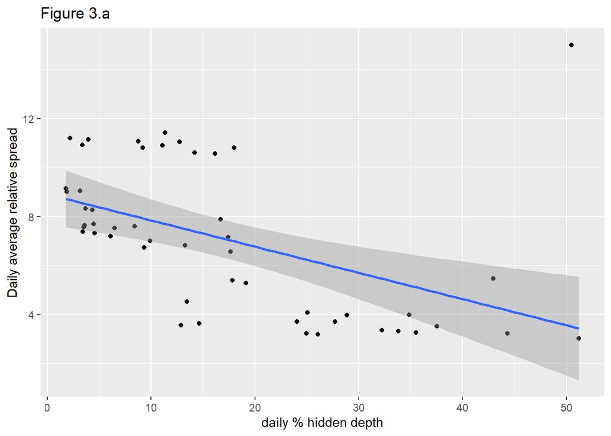

```r
MP<-Stock1LOBLEV[sign==1 | sign==-1,.(midpoint =sum(quote)/2), by="date,time"]
Stock1LOBLEV<- Stock1LOBLEV[MP,on = c(date="date",time="time")]
RS<- Stock1LOBLEV[sign==1,.(RS = abs(midpoint - quote)*2/midpoint), by=.(date,time)]
Stock1LOBLEV <- Stock1LOBLEV[RS, on=c(date="date",time="time")]


Stock1LOBLEV[sign<0,type:="ask"]
Stock1LOBLEV[sign>0,type:="bid"]


Stock1LOBLEV[,vol:=hidden+displayed,by="date,time,type"]
Stock1LOBLEV[,cumvol:=(sum(vol)),by="date,time,type"]

vol10k<-Stock1LOBLEV[,max(cumvol),by="date,time,type"][,.(min(V1)>10000),by="date,time"][V1==T,.(date,time)]

vol10k<-merge(vol10k,Stock1LOBLEV)

cumfun<- function(x){
  l<-length(x)
  cumsum=0
  volused=0
  for (i in 1:l) {
    if((10000-cumsum)-(x[i])<0){volused[i]=10000-cumsum}
    else{volused[i]=x[i]}
  cumsum=cumsum+volused[i]
  }

  return(volused)}

vol10k[,volused:=cumfun(vol), by="date,time,type"]


vol10k[, VW := sum((volused*quote)/sum(volused)), by="date,time,type"]

VWRS <- vol10k[, .(max(VW),max(midpoint)), by="date,time,type"][,max((diff(V1)/V2)),by="date,time"]
vol10k <- vol10k[VWRS, on=c(date="date",time="time")]

dailyhidden <- vol10k[, sum(hidden)/sum(hidden+displayed), by="date"]
dailyrs <- vol10k[,mean(RS),by="date"]
dailyvwrs <- vol10k[,mean(V1), by="date"]


ggplot(,aes(dailyhidden$V1*100,dailyrs$V1*10000))+geom_point()+ geom_smooth(method = "lm")+
  ggtitle("Figure 3.a")+xlab("daily % hidden depth")+ylab("Daily average relative spread")
```

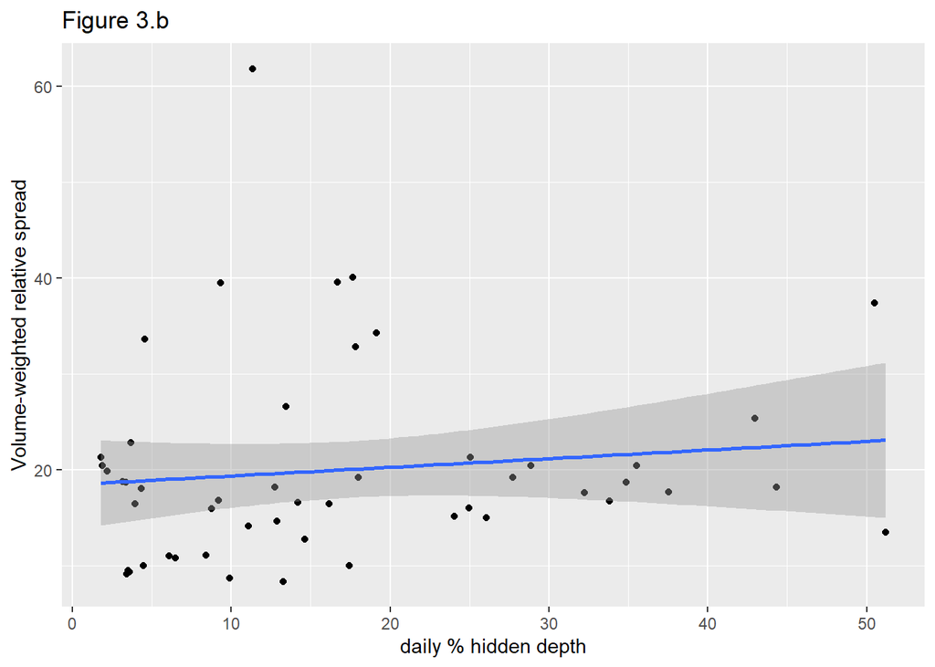

```r
ggplot(,aes(dailyhidden$V1*100,dailyvwrs$V1*10000))+geom_point()+ geom_smooth(method = "lm")+
  ggtitle("Figure 3.b")+xlab("daily % hidden depth")+ylab("Volume-weighted relative spread")
```

## THIRD TASK

Let’s now compare the displayed LOB with the hidden LOB. The existence a hidden book can benefit liquidity takers in several ways: (a) they can execute trades at better quotes than displayed (price improvements), (b) trade more than apparently available at the best displayed quotes; (c) as a result of (a), paying lower premiums or discounts for immediacy. You are asked now to evaluate the actual relevance of these potential benefits.

### How often traders can get price improvements because of the presence of hidden volume in the book?

To answer this question, examine how often either the best displayed ask or bid quote are actually worse than the actual best quote (i.e., accounting for the hidden LOB). Can you quantify how important that improvement could actually be? Provide findings for the whole trading session and for the first 30 minutes of trading separately.

```r
Stock1LOBLEV[displayed==0, bestquote := 100]
Stock1LOBLEV[displayed>0, bestquote := min(dist), by="date,time,type"]
Stock1LOBLEV[, bestquote2 := min(bestquote), by="date,time,type"]
bestquotes <- Stock1LOBLEV[dist==bestquote2,quote,by="date,time,type"]
Stock1LOBLEV<- Stock1LOBLEV[bestquotes, on=c(date="date",time="time",type="type")]


Stock1LOBLEV[,DRS := abs(midpoint - i.quote)*2/midpoint]


PrImprAskAll <- round((dim((Stock1LOBLEV[type=="ask" & dist==0 & displayed==0 & hidden>0]))[1])/(dim(Stock1LOBLEV)[1])*100,4)
PrImprBidAll <- round((dim((Stock1LOBLEV[type=="bid" & dist==0 & displayed==0 & hidden>0]))[1])/(dim(Stock1LOBLEV)[1])*100,4)
PrImprAsk30 <- round((dim((Stock1LOBLEV[type=="ask" & dist==0 & displayed==0 & hidden>0 & time < 36060]))[1])/(dim(Stock1LOBLEV)[1])*100,4)
PrImprBid30 <- round((dim((Stock1LOBLEV[type=="bid" & dist==0 & displayed==0 & hidden>0 & time < 36060]))[1])/(dim(Stock1LOBLEV)[1])*100,4)
```

###How often can they get depth improvements? To answer the question, examine how often there is hidden volume at the best quotes, when the displayed quotes equal the best quotes available. Can you quantify how important that depth improvement could actually be? Provide findings for the whole trading session and for the first 30 minutes of trading separately.

```r
DeImpAskAll <- round((dim((Stock1LOBLEV[type=="ask" & dist==0 & displayed>0 & hidden>0]))[1])/(dim(Stock1LOBLEV)[1])*100,4)
DeImpBidAll <- round((dim((Stock1LOBLEV[type=="bid" & dist==0 & displayed>0 & hidden>0]))[1])/(dim(Stock1LOBLEV)[1])*100,4)
DeImpAsk30 <- round((dim((Stock1LOBLEV[type=="ask" & dist==0 & displayed>0 & hidden>0 & time < 36060]))[1])/(dim(Stock1LOBLEV)[1])*100,4)
DeImpBid30 <- round((dim((Stock1LOBLEV[type=="bid" & dist==0 & displayed>0 & hidden>0 & time < 36060]))[1])/(dim(Stock1LOBLEV)[1])*100,4)
RSall<-round(Stock1LOBLEV[, mean(RS)]*100,4)
DRSall<-round(Stock1LOBLEV[, mean(DRS)]*100,4)

RS30<-round(Stock1LOBLEV[time < 36060, mean(RS)]*100,4)
DRS30<-round(Stock1LOBLEV[time < 36060, mean(DRS)]*100,4)
```

```r
t.test(Stock1LOBLEV[, (RS)],Stock1LOBLEV[time < 36060, (RS)])
```

```
##
##  Welch Two Sample t-test
##
## data:  Stock1LOBLEV[, (RS)] and Stock1LOBLEV[time < 36060, (RS)]
## t = -23.878, df = 34594, p-value < 2.2e-16
## alternative hypothesis: true difference in means is not equal to 0
## 95 percent confidence interval:
##  -0.0001559457 -0.0001322860
## sample estimates:
##    mean of x    mean of y
## 0.0007904868 0.0009346026
```

```r
t.test(Stock1LOBLEV[, (DRS)],Stock1LOBLEV[time < 36060, (DRS)])
```

```
##
##  Welch Two Sample t-test
##
## data:  Stock1LOBLEV[, (DRS)] and Stock1LOBLEV[time < 36060, (DRS)]
## t = -30.066, df = 33884, p-value < 2.2e-16
## alternative hypothesis: true difference in means is not equal to 0
## 95 percent confidence interval:
##  -0.0002176780 -0.0001910336
## sample estimates:
##    mean of x    mean of y
## 0.0008469322 0.0010512880
```

```r
impro.dt <- matrix(c(paste0(RSall,"***"),paste0(DRSall,"***"),PrImprAskAll,DeImpAskAll,PrImprBidAll,DeImpBidAll,
                     RS30,DRS30,PrImprAsk30,DeImpAsk30,PrImprBid30,DeImpBid30), ncol=6, byrow = T)
colnames(impro.dt) = c("RS", "DRS", "PrImpAsk", "DeImprAsk","PrImpBid","DeImpBid")
rownames(impro.dt) = c("All intervals", "First 30 minutes")

kable(impro.dt, caption="Table 2")
```

[output not shown]

## FORTH TASK

Evaluate how much depth is hidden per 30‐minute interval at the cross‐sectional level. That is, first compute averages across stocks per 30‐minute interval. Average the statistics for the ask and bid sides of the book and plot the estimated regular pattern in Figure 4.a (for the whole LOB), and Figure 4.b (controlling for aggressiveness). What do you observe?

Next investigate in market capitalization matters in the order exposure decision. That is, you are now aimed to answer the question of whether traders hide more often when providing liquidity for large or for small caps. In order to do that, you must group the 120 stocks in three subsamples based on market capitalization: large, medium, and small caps. You need the file CapGroup.txt you already used in the First Assignment. Split the data in HidStatSample.txt into three pieces based on market capitalization, and compute average statistics per each 30‐minute interval. Repeat the exercise in Figure 4 but this time for the three subsamples of stocks, and plot the resulting intraday regular patterns in Figure 5 (no need to control for aggressiveness). What do you conclude? What theoretical framework reviewed during the course is consistent with your findings?

```r
plotter<-function(data){data<-as.data.table(data)
  dat<-as.data.table(cbind(id=1:length(data[[1]]),data))
  datmelt<-melt(id.vars="id",dat)
 ggplot(datmelt,
         aes(x = id, y = value, color=variable))+theme_bw()+
    xlab("X LABEL")+ylab("Y LABEL")+geom_line()+
    ggtitle("TITLE")
}
```

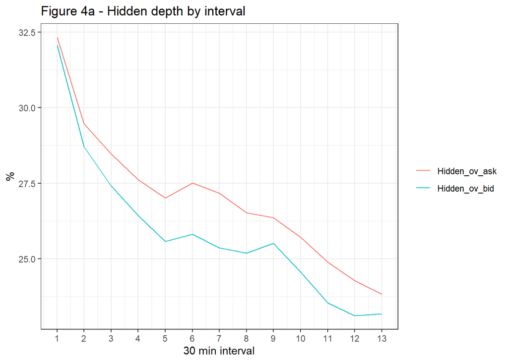

```r
scnd_dt<-fread("C:/Users/Jt_an/Google Drive/GSE - Finance/2 trim_/HFT/Assignments/THIRD/HidStatSample.txt")
capgroup_dt<-fread("C:/Users/Jt_an/Google Drive/GSE - Finance/2 trim_/HFT/Assignments/THIRD/CapGroup.txt")#Recall 1 is large and 3 is small
setnames(capgroup_dt,"Stock","stock")
scnd_dt<-merge(scnd_dt,capgroup_dt,by="stock")
#third_dt<-fread("DailyHidVol.txt")
seq_aux<-seq(34260,57660,1800)
for (i in 1:length(seq_aux)){
scnd_dt[time>=seq_aux[i]&time<=seq_aux[i+1],interval:=i]}

#Average hidden orders, ask and bid sides by 30 min interval
fig4a<-scnd_dt[,.(Hidden_ov_ask=mean(HLOBAsk),Hidden_ov_bid=mean(HLOBBid)),by=interval]

plotter(fig4a[,2:3]*100)+ggtitle("Figure 4a - Hidden depth by interval")+theme(legend.title = element_blank())+xlab("30 min interval")+ylab("%")+ scale_x_continuous(breaks = seq(1, 13, by = 1))
```

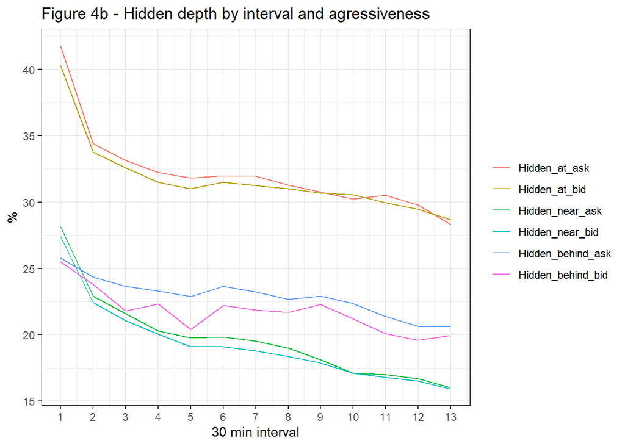

```r
#Average hidden orders, ask and bid sides by 30 min interval and agressiveness
fig4b<-scnd_dt[,.(Hidden_at_ask=mean(HAtAsk),Hidden_at_bid=mean(HAtBid),Hidden_near_ask=mean(HNearAsk),Hidden_near_bid=mean(HNearBid),Hidden_behind_ask=mean(HFarAsk),Hidden_behind_bid=mean(HFarBid)),by=interval]
plotter(fig4b[,2:length(fig4b)]*100)+ggtitle("Figure 4b - Hidden depth by interval and agressiveness")+theme(legend.title = element_blank())+xlab("30 min interval")+ylab("%")+ scale_x_continuous(breaks = seq(1, 13, by = 1))
```

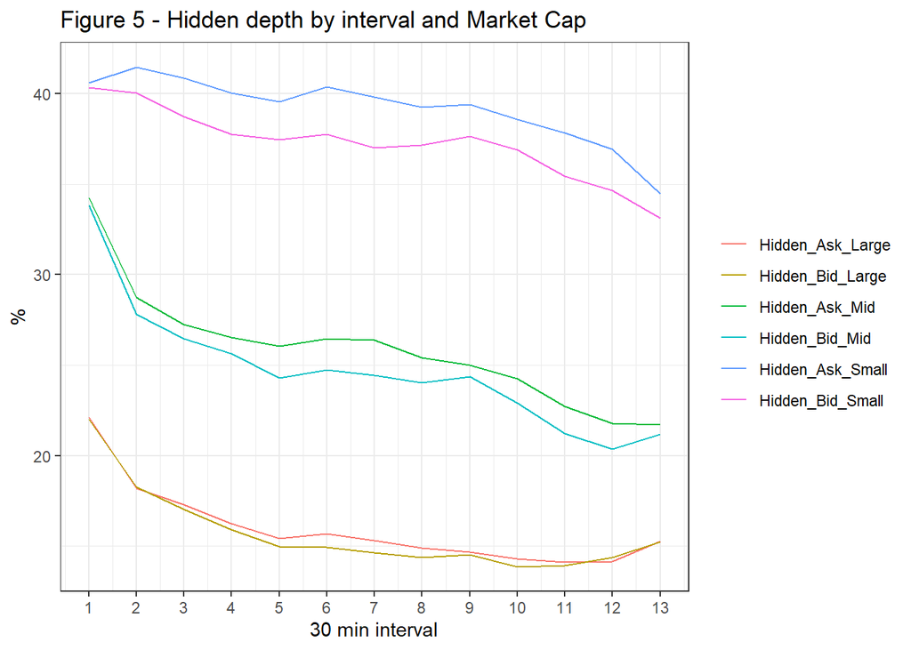

```r
#Average hidden orders, ask and bid sides by 30 min interval and cap size
fig5<-scnd_dt[,.(Hidden_ov_ask=mean(HLOBAsk),Hidden_ov_bid=mean(HLOBBid)),by=c("interval","Capgroup")]
plotter(cbind(Hidden_Ask_Large=fig5[Capgroup==1]$Hidden_ov_ask*100,Hidden_Bid_Large=fig5[Capgroup==1]$Hidden_ov_bid*100,Hidden_Ask_Mid=fig5[Capgroup==2]$Hidden_ov_ask*100,Hidden_Bid_Mid=fig5[Capgroup==2]$Hidden_ov_bid*100,Hidden_Ask_Small=fig5[Capgroup==3]$Hidden_ov_ask*100,Hidden_Bid_Small=fig5[Capgroup==3]$Hidden_ov_bid*100))+theme(legend.title = element_blank())+ylab("%")+xlab("30 min interval")+ggtitle("Figure 5 - Hidden depth by interval and Market Cap")+ scale_x_continuous(breaks = seq(1, 13, by = 1))
```

## FIFTH TASK

Finally, we study whether the likelihood of hiding (and therefore market opacity) varies with price volatility. As a preliminary step, I have generated daily average statistics on dark liquidity for the whole LOB (“All”), depth at the best quotes (“At”), depth near the best quotes (“Near”), and depth far from the best quotes (“Behind”) for each of the 120 stocks in the sample. Those statistics can be found in the file DailyHidVol.txt. Now, using the file NasdaqVolat.txt (First Assignment), select the 10 days with highest and lowest volatility levels per stock. Using the selected days per stock, you are asked to generate a table containing median differences in hidden volume use between high volatility and low volatility days, and statistical tests (Wilcoxon’s non‐parametric rank‐sum tests) on the significance of those differences. As a complementary test, you are asked to run a simple regression model. You must follow the same steps as in the First Assignment

```r
dt5<-merge(fread("C:/Users/Jt_an/Google Drive/GSE - Finance/2 trim_/HFT/Assignments/THIRD/NasdaqVolat.txt"),fread("C:/Users/Jt_an/Google Drive/GSE - Finance/2 trim_/HFT/Assignments/THIRD/DailyHidVol.txt"),by=c("date","stock"))

maxvoldates<-dt5[order(stock,-volat),head(date,10),by=stock]#high vol days
setnames(maxvoldates,"V1","date")
maxvoldates<-maxvoldates[,volatility:="high"]

minvoldates<-dt5[order(stock,volat),head(date,10),by=stock]#low vol days
setnames(minvoldates,"V1","date")
minvoldates<-minvoldates[,volatility:="low"]

dt_byvol<-rbind(merge(dt5,maxvoldates,by=c("date","stock")),merge(dt5,minvoldates,by=c("date","stock")))

dt_byvol<-dt_byvol[order(stock)]

#Now we compute medians and recover p-values from Wilcox tests of equality of medians
#All book
#median(dt_byvol[volatility=="high"]$hbook-dt_byvol[volatility=="low"]$hbook)
wilcox.test(dt_byvol[volatility=="high"]$hbook,dt_byvol[volatility=="low"]$hbook)[[3]]#significant difference at 1%
```

```
## [1] 1.209806e-09
```

```r
#At
#median(dt_byvol[volatility=="high"]$hat-dt_byvol[volatility=="low"]$hat)
wilcox.test(dt_byvol[volatility=="high"]$hat,dt_byvol[volatility=="low"]$hat)[[3]]#significant difference at 1%
```

```
## [1] 2.01221e-43
```

```r
#Near
#median(dt_byvol[volatility=="high"]$hnear-dt_byvol[volatility=="low"]$hnear)
wilcox.test(dt_byvol[volatility=="high"]$hnear,dt_byvol[volatility=="low"]$hnear)[[3]]#significant difference at 1%
```

```
## [1] 1.22505e-42
```

```r
#Far
#median(dt_byvol[volatility=="high"]$hfar-dt_byvol[volatility=="low"]$hfar)
wilcox.test(dt_byvol[volatility=="high"]$hfar,dt_byvol[volatility=="low"]$hfar)[[3]]# NO significant difference at 1%
```

```
## [1] 0.4524416
```

```r
table_3<-matrix(nrow=1,ncol=4)
rownames(table_3)<-"High - Low volatility"
colnames(table_3)<-c("All","At","Near","Far")

table_3[1]<-paste0(round(median((dt_byvol[volatility=="high"]$hbook-dt_byvol[volatility=="low"]$hbook)*100),2),"%","***")
table_3[2]<-paste0(round(median((dt_byvol[volatility=="high"]$hat-dt_byvol[volatility=="low"]$hat)*100),1),"%","***")
table_3[3]<-paste0(round(median((dt_byvol[volatility=="high"]$hnear-dt_byvol[volatility=="low"]$hnear)*100),1),"%","***")
table_3[4]<-paste0(round(median((dt_byvol[volatility=="high"]$hfar-dt_byvol[volatility=="low"]$hfar)*100),1),"%")
kable(table_3, caption="Table 3")
```

[output not shown]

```r
#Now we run some regressions of hidden volume on volatility by aggressiveness

dt_byvol[volatility=="high",highvol:=1]
dt_byvol[volatility=="low",highvol:=0]
dt_byvol[volatility=="low"]
```

[output not shown]

```r
#OLS_all<-summary(lm(daily_median_5dbest~vol_1H_0L,data=filtered_liqlob))

table4_OLS_all<-summary(lm(hbook~highvol,data=dt_byvol))
table4_OLS_at<-summary(lm(hat~highvol,data=dt_byvol))
table4_OLS_near<-summary(lm(hnear~highvol,data=dt_byvol))
table4_OLS_far<-summary(lm(hfar~highvol,data=dt_byvol))

table4_OLS_all$coefficients[,1]
```

```
## (Intercept)     highvol
##   0.2909580   0.0484725
```

```r
table4_OLS_at$coefficients[,1]
```

```
## (Intercept)     highvol
##   0.4153453   0.1190441
```

```r
table4_OLS_near$coefficients[,1]
```

```
## (Intercept)     highvol
##   0.2768574   0.1122052
```

```r
table4_OLS_far$coefficients[,1]
```

```
## (Intercept)     highvol
##  0.28299001  0.01160984
```

```r
#Except for far, all betas are significant at under the 1% level
```